# data-analysis-replication

# This paper seeks to develop a method for the determination of Inka building stones’ geological provenances using portable x-ray fluorescence (pXRF) spectrometry. Ogburn et al. present pXRF readings taken on weathered and fresh samples of stone to determine the degree of contamination on weathered samples as compared with fresh ones. The authors seek to determine whether archaeologists can reliably use pXRF readings of building stone surfaces to compare with geological samples, or whether the contamination of the exterior surface interferes with the results of analysis.

# This paper includes mean, standard deviation, t-test, and f-test analyses of the data obtained from the pXRF readings. There are also bivariate plots of the readings for each element, comparing between materials from the Rumiqolqa and Huaccoto quarries. Using the data sets for the Rumiqolqa and Huaccoto materials, I will determine the mean and standard deviation of the Rumiqoqla set, in addition to performing a t- and f-test on the data. I will then re-create a bivariate plot with the readings for K on weathered and fresh samples of Rumiqolqa and Huaccoto materials.

```r
library(tidyverse)
library(dplyr)
#Loading Rumiqolqa data set
rumi <- read_csv(file="~/DEVELOPMENT/HOMEWORK/EARLE-JULIA-ADA-DATA-REANALYSIS-ASSIGNMENT/EARLE-JULIA-ADA-DATA-REANALYSIS-ASSIGNMENT/rumiqolqa.csv")
head(rumi)
```

```
## # A tibble: 6 x 23
##   Site  `K fresh` `K weathered` `Ca fresh` `Ca weathered` `Ti fresh`
##   <chr>     <dbl>         <dbl>      <dbl>          <dbl>      <dbl>
## 1 Rumi…     47255         47065      29657          25216       4925
## 2 <NA>      48187         46254      26604          26177       6460
## 3 <NA>      44752         41029      26832          23982       4658
## 4 <NA>      47647         38831      25168          19313       4334
## 5 <NA>      46297         47458      28163          27500       5083
## 6 <NA>      51826         43876      27929          26314       4791
## # … with 17 more variables: `Ti weathered` <dbl>, `Mn fresh` <dbl>, `Mn
## #   weathered` <dbl>, `Fe fresh` <dbl>, `Fe weathered` <dbl>, `Zn
## #   fresh` <dbl>, `Zn weathered` <dbl>, `Rb fresh` <dbl>, `Rb
## #   weathered` <dbl>, `Sr fresh` <dbl>, `Sr weathered` <dbl>, `Zr
## #   fresh` <dbl>, `Zr weathered` <dbl>, `Ba fresh` <dbl>, `Ba
## #   weathered` <dbl>, `Pb fresh` <dbl>, `Pb weathered` <dbl>
```

```r
#Loading Huaccoto data set
huac <- read_csv(file="~/DEVELOPMENT/HOMEWORK/EARLE-JULIA-ADA-DATA-REANALYSIS-ASSIGNMENT/EARLE-JULIA-ADA-DATA-REANALYSIS-ASSIGNMENT/huaccoto.csv")
head(huac)
```

```
## # A tibble: 6 x 31
##   Site  Date  Time  P     `P +/-` S     `S +/-` Cl    `Cl +/-` `K fresh`
##   <chr> <lgl> <lgl> <lgl> <lgl>   <lgl> <lgl>   <lgl> <lgl>        <dbl>
## 1 Huac… NA    NA    NA    NA      NA    NA      NA    NA           43969
## 2 <NA>  NA    NA    NA    NA      NA    NA      NA    NA           47500
## 3 <NA>  NA    NA    NA    NA      NA    NA      NA    NA           48176
## 4 <NA>  NA    NA    NA    NA      NA    NA      NA    NA           42497
## 5 <NA>  NA    NA    NA    NA      NA    NA      NA    NA           50161
## 6 <NA>  NA    NA    NA    NA      NA    NA      NA    NA           42834
## # … with 21 more variables: `K weathered` <dbl>, `Ca fresh` <dbl>, `Ca
## #   weathered` <dbl>, `Ti fresh` <dbl>, `Ti weathered` <dbl>, `Mn
## #   fresh` <dbl>, `Mn weathered` <dbl>, `Fe fresh` <dbl>, `Fe
## #   weathered` <dbl>, `Zn fresh` <dbl>, `Zn weathered` <dbl>, `Rb
## #   fresh` <dbl>, `Rb weathered` <dbl>, `Sr fresh` <dbl>, `Sr
## #   weathered` <dbl>, `Zr fresh` <dbl>, `Zr weathered` <dbl>, `Ba
## #   fresh` <dbl>, `Ba weathered` <dbl>, `Pb fresh` <dbl>, `Pb
## #   weathered` <dbl>
```

```r
#Means of K measurements from fresh and weathered samples
kf <- mean(rumi$`K fresh`)
kw <- mean(rumi$`K weathered`)
kf
```

```
## [1] 48444.58
```

```r
kw
```

```
## [1] 45673.32
```

## Replications/Reanalysis

```r
#SD of K measurements from fresh and weathered samples
kfsd <- sd(rumi$`K fresh`)
kwsd <- sd(rumi$`K weathered`)
kfsd
```

```
## [1] 2018.34
```

```r
kwsd
```

```
## [1] 5353.505
```

```r
#T-test for K
x <- rumi$`K fresh` - rumi$`K weathered`
n <- length(x)
t.test(rumi$`K fresh`, rumi$`K weathered`, df = n - 1, alternative = "two.sided", paired = TRUE)
```

```
##
##  Paired t-test
##
## data:  rumi$`K fresh` and rumi$`K weathered`
## t = 2.3641, df = 18, p-value = 0.02952
## alternative hypothesis: true difference in means is not equal to 0
## 95 percent confidence interval:
##   308.5323 5233.9940
## sample estimates:
## mean of the differences
##                2771.263
```

```r
#F test for K
x <- rumi$`K fresh`
y <- rumi$`K weathered`
vt <- var.test(x, y)
vt
```

```
##
##  F test to compare two variances
##
## data:  x and y
## F = 0.14214, num df = 18, denom df = 18, p-value = 0.0001352
## alternative hypothesis: true ratio of variances is not equal to 1
## 95 percent confidence interval:
##  0.05476156 0.36893405
## sample estimates:
## ratio of variances
##          0.1421387
```

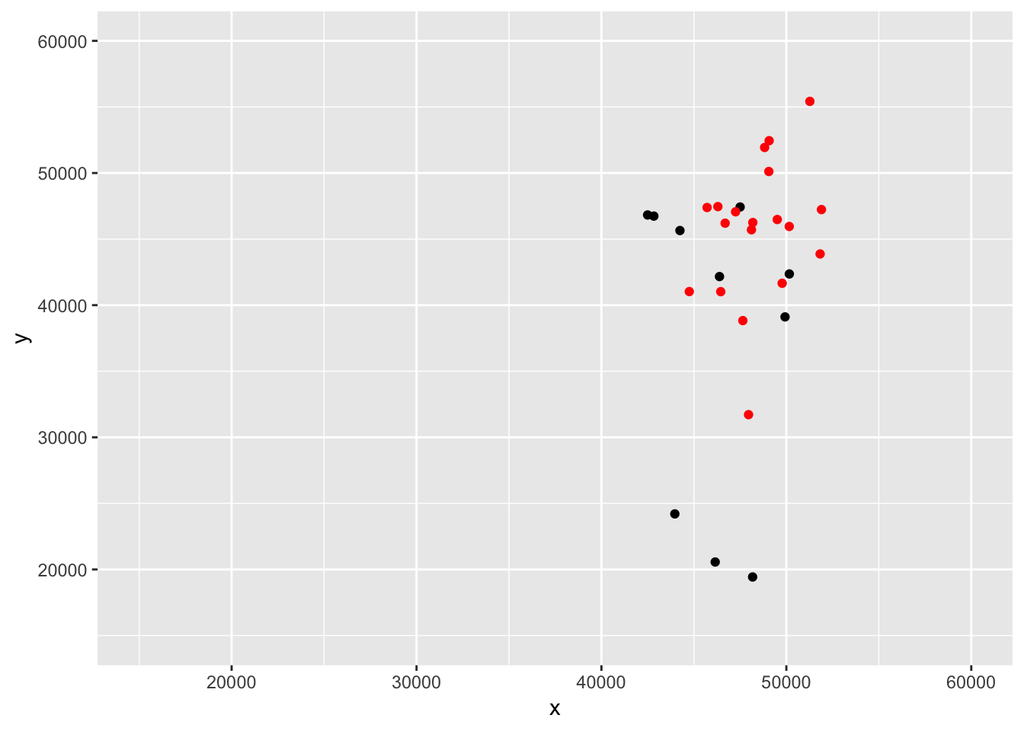

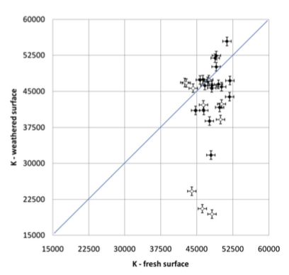

```r
library(ggplot2)
library(gridExtra)
#Making bivariate plot displaying readings of K from weathered and fresh surfaces
kh = data.frame(x = huac$`K fresh`, y = huac$`K weathered`)
kr = data.frame(x = rumi$`K fresh`,y = rumi$`K weathered`)
ggplot(kh, aes(x,y)) + geom_point() + geom_point(data=kr, colour='red') + xlim(15000, 60000) + ylim(15000, 60000)
```